# Support Vector Machines

[benjburgess.github.io](https://benjburgess.github.io/)

[Support Vector Machines](https://benjburgess.github.io/data/index/svm)

# Advanced Tutorial

## Introduction

As I’ve detailed in the [introduction to support vector machines (SVMs)](https://benjburgess.github.io/data/index/svm), SVMs are a machine learning tool which can be used to classify data into two or more different groups. Outlined below is an example of how an SVM approach can be applied to a relatively complex dataset, in this case considering the properties of a large number of different wines. Here, we will build a SVM capable of accurately classifying the quality of wine based on its chemical properties. Here, quality is a category between 1 and 10, with one reflecting the lowest quality wine and 10 the highest quality wine. For this example, we will be using `R`.

The first thing to do is download the data and save it to your local machine. The data is available from [Kaggle](https://www.kaggle.com/shelvigarg/wine-quality-dataset) and is from an academic paper by [Cortez et al. (2009)](https://www.sciencedirect.com/science/article/abs/pii/S0167923609001377).

Throughout this tutorial, code chunks will have a blue background and output will have a green background. This tutorial is meant to be a relatively advanced example of SVMs, particularly with regards to the number of different classes (i.e., wine qualities) and data cleaning. For a simpler workflow of SVMs in R, see the [Introductory Tutorial on SVMs](https://benjburgess.github.io/i/SVM_linear). Importantly, these tutorial also addresses some of the issues of analyses using SVMs.

## Scenario

For this tutorial we will attempt to find a solution to the following scenario.

Let’s imagine we work at a wine merchants, which specialises in mid-range wines. Our company is about to have a new shipment of white wines come in, and wants to know how to price these new wines. In order to do this, the company needs to work out their quality, with higher quality wines likely to command a higher price than those of a lower quality. The company knows that these wines will all be mid-range wines, but does not known whether each wine will be of i) a lower-medium quality (quality class of 5); ii) a medium quality (quality class of 6); or iii) a higher-medium quality (quality class of 7). The company has large-scale dataset on previous wines detailing their quality and a number of chemical properties. As such, the company wants us to generate a model which is capable of determining each wines’ quality from the its chemical properties. In particular, the company is keen for the model not to misclassify wines of lower-medium (5) quality as higher-medium (7) quality (and vice versa) as this may result in customers being particularly overcharged for wines (and potentially dissatisfied customers) or particularly undercharged for wines (lower profits for the company). The company also wants to avoid wines of medium (6) and higher-medium (7) being assigned a lower quality as much as possible given this may harm profits (but is unlikely to unduly harm customer satisfaction).

As detailed above, we are going to attempt to meet the companies aims using a support vector machine.

## Packages and set.seed()

Firstly, we need to load the various packages we need for this tutorial. If any of these packages are not installed in your local machine, they can be installed via the `install.packages()` function. We will also set the seed for this code, this is simply to allow reproducibility of the results.

```r
library(ggplot2)
library(data.table)
library(scales)
library(scutr)
library(caret)
library(caTools)
library(dplyr)

set.seed(7654)
```

## Data loading

The next thing we need to do is load in the data. This will be from wherever you saved the data on your local machine and whatever you titled the file (see the above link). This data represents the dataset referred to in the scenario.

At this point we will also change some of the column names. In the original file there were blank spaces which `R` isn’t a fan of. The following code will also convert any of these blank spaces to underscores.

```r
df <- fread("~/R_sandbox/Wine_Data_Kaggle.csv", data.table=FALSE)

colnames(df) <- gsub(" ", "_", colnames(df))

head(df)
```

```
##    type fixed_acidity volatile_acidity citric_acid residual_sugar chlorides
## 1 white           7.0             0.27        0.36           20.7     0.045
## 2 white           6.3             0.30        0.34            1.6     0.049
## 3 white           8.1             0.28        0.40            6.9     0.050
## 4 white           7.2             0.23        0.32            8.5     0.058
## 5 white           7.2             0.23        0.32            8.5     0.058
## 6 white           8.1             0.28        0.40            6.9     0.050
##   free_sulfur_dioxide total_sulfur_dioxide density   pH sulphates alcohol
## 1                  45                  170  1.0010 3.00      0.45     8.8
## 2                  14                  132  0.9940 3.30      0.49     9.5
## 3                  30                   97  0.9951 3.26      0.44    10.1
## 4                  47                  186  0.9956 3.19      0.40     9.9
## 5                  47                  186  0.9956 3.19      0.40     9.9
## 6                  30                   97  0.9951 3.26      0.44    10.1
##   quality
## 1       6
## 2       6
## 3       6
## 4       6
## 5       6
## 6       6
```

## Data cleaning

At this point when checking our data it is apparent that there are a few rows with missing data. For our analysis we will remove these rows as they will convolute any analysis.

```r
original.dim <- dim(df)[1]

df <- na.omit(df)

new.dim <- dim(df)[1]

original.dim - new.dim
```

```
## [1] 34
```

As you can see there are 34 rows which have been removed from our dataframe.

At this stage we can remove the redundant data from our dataset. Our project brief is to develop a model which is capable of predicting the quality of *mid-range* *white* wines. As such, we can remove all data from our dataset on red wines. We can also remove all the data on higher and lower quality wines as these are not part of the brief and may only convolute our analyses.

This subsetting can be done with the following code.

```r
#only select white wines
df <- subset(df, type == "white")

#remove 'type' column as our dataset is now entirely white wines
df <- df[,-1]

#only select mid quality wines and set quality as a factor
df <- subset(df, quality  %in% c(5, 6, 7))

df$quality <- factor(df$quality)
```

At this point we need to split our data into two distinct subsets. The first will be used for training the svm (the train dataset) and the second will be used for testing the dataset.Here, we will be splitting our data while preserving the same ratio of wines of each quality (5, 6, 7) in both the test and train datasets.

Our analysis is going to be run on the training dataset before being tested on the test dataset right at the very end of the analysis.

For our analysis, the training dataset will comprise 70% of the dataset and the test datset will comprise 30% of the original dataset. Although a 70/30 split is relatively common, other analyses may use a different split (e.g., 67/33) for the training and test datasets.

This can be done using the following code.

```r
split_determined  <- sample.split(df$quality, SplitRatio = 0.7)
df.train <- df[split_determined,]
df.test  <- df[!split_determined,]
```

Now if we look at our train and test dataset one thing we can easily notice is that the different variables are all on different scales.

```r
head(df.train)
```

```
##   fixed_acidity volatile_acidity citric_acid residual_sugar chlorides
## 1           7.0             0.27        0.36           20.7     0.045
## 2           6.3             0.30        0.34            1.6     0.049
## 3           8.1             0.28        0.40            6.9     0.050
## 4           7.2             0.23        0.32            8.5     0.058
## 5           7.2             0.23        0.32            8.5     0.058
## 7           6.2             0.32        0.16            7.0     0.045
##   free_sulfur_dioxide total_sulfur_dioxide density   pH sulphates alcohol
## 1                  45                  170  1.0010 3.00      0.45     8.8
## 2                  14                  132  0.9940 3.30      0.49     9.5
## 3                  30                   97  0.9951 3.26      0.44    10.1
## 4                  47                  186  0.9956 3.19      0.40     9.9
## 5                  47                  186  0.9956 3.19      0.40     9.9
## 7                  30                  136  0.9949 3.18      0.47     9.6
##   quality
## 1       6
## 2       6
## 3       6
## 4       6
## 5       6
## 7       6
```

[This is an issue for SVMs](https://stats.stackexchange.com/questions/65094/why-scaling-is-important-for-the-linear-svm-classification/224201), as if data is on different scales there is the potential for the numerically larger variables to be given a greater importance than the numerically smaller variables. This then has the potential to bias our model. As such, we need to rescale each variable to be on the same scale. This can be done with the following code, [see this stackoverflow link for more details](https://datascience.stackexchange.com/questions/13971/standardization-normalization-test-data-in-r).

```r
train_scaling <- preProcess(df.train, method=c("scale", "center"))
df.train <- predict(train_scaling, df.train)
df.test  <- predict(train_scaling, df.test)
```

This code ensures that the test and train datasets are both scaled in the same way. If they weren’t when we come to test the SVM, all our model predictions would be wrong as the test and train datasets would be subtely different. As such, our test dataset is rescaled using the rescaling factors from our train dataset.

If we have a look at our train dataset, we can plot a histogram of the different count of wines in each of the different categories.

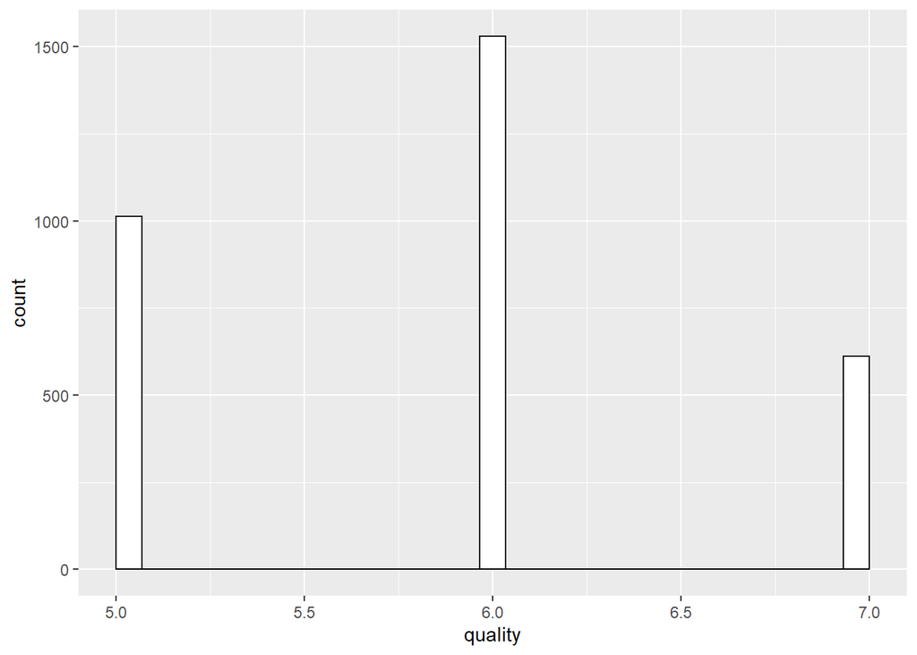

```r
ggplot(df.train, aes(x=as.numeric(as.character(quality)))) +
  geom_histogram(color="black", fill="white") +
  xlab("quality")
```

As we can, see there are more wines of quality 6, then there are of quality 5 or 7. This may be an issue with our SVM, as it may therefore be inherently biased towards predicting wines of quality 6. As such, we could in theory get a reasonable accuracy for our SVM if it predicted group 6 accurately but the other groups poorly. This would represent a biased model. As such one way we can go about this is using a technique called SMOTE or SCUT to rebalance our dataset to have equal proportions of each of the different wine qualities. SMOTE [(explained more here)](https://towardsdatascience.com/a-practical-guide-to-interpreting-and-visualising-support-vector-machines-97d2a5b0564e) is method for generating new data based on existing data in the same group. I’m not going to go into it too much here, but this technique uses the nearest neighbour algorithm to generate new data. SMOTE is the method to use if your data only contains two groups, while SCUT is the method to use if your data comprises three or more groups. Here, we have three different groups so we will be using SCUT. Note that SCUT only needs to be conducted on the train dataset, not the test dataset.

SCUT can be used from the `scutr` package, and run using the following code.

```r
df.train <- SCUT(df.train, "quality", oversample="oversample_smote")
```

As such if we replot our dataset, using the following code, we can see that we’ve now got equal counts of each of the wine qualities in our dataset.

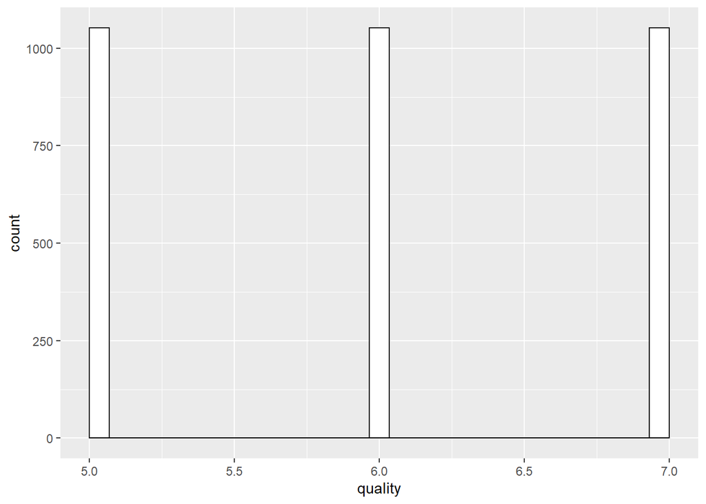

```r
ggplot(df.train, aes(x=as.numeric(as.character(quality)))) +
  geom_histogram(color="black", fill="white") +
  xlab("quality")
```

Our dataset is relatively complex, containing data on a dozen or so chemical properties of each wine. At this stage, we are going try and reduce some of this complexity by implementing a dimensionality reduction procedure to the dataset. In essence, this reformats our dataset into a number of components which account for varying amounts of variance within our dataset. These components no longer account for different variables, but instead different variables are grouped together. Here, we will using principal component analysis (i.e., PCA) to reduce the dimensionality of our dataset. This can be done with the following code:

```r
#conduct a principal component analysis using the train dataset


#remove the qualities from the train dataset
pca_train <- prcomp(df.train[-c(12)])

summary(pca_train)
```

```
## Importance of components:
##                          PC1    PC2    PC3    PC4    PC5     PC6     PC7
## Standard deviation     1.861 1.2565 1.1768 1.1507 1.0297 0.96716 0.88395
## Proportion of Variance 0.293 0.1336 0.1172 0.1120 0.0897 0.07914 0.06611
## Cumulative Proportion  0.293 0.4266 0.5438 0.6558 0.7455 0.82463 0.89074
##                            PC8    PC9    PC10    PC11
## Standard deviation     0.75925 0.6441 0.53317 0.12568
## Proportion of Variance 0.04877 0.0351 0.02405 0.00134
## Cumulative Proportion  0.93951 0.9746 0.99866 1.00000
```

Now, we need to make a decision about the number of principal components to select for our analyses. There are various different ways of selecting which principal components to use. Two of the most common methods are the variance explained criteria or the Kaiser-Guttman criterion [(see this link for a thorough explanation of selecting principal components)](https://www.geo.fu-berlin.de/en/v/soga/Geodata-analysis/Principal-Component-Analysis/principal-components-basics/Choose-principal-components/index.html). In short, the variance explained criteria suggests that the user should select principal components which explain the variance up to a certain cut-off point. So, by starting with PC1 we would continue to select PCs (in descending order of variance explained) up until our threshold is met (with 70-90% of variance being common thresholds). In contrast, the Kaiser-Guttman criterion says that only those PCs which have a variance (squared SD) of over 1 should be selected. Here, following the different methods may result in a different number of PCs being selected. If we use a threshold of 80% variance explained, we would select PCs 1-6. However, if use the Kaiser-Guttman criterion, then only PCs 1-5 would be selected. Here, for the purposes of this tutorial, we are going to use the variance explained criteria (with a threshold of 90%) and only select the first eight PCs. Selecting PCs 1-8 can be done using the following code (which also applies the identical PCA transformation to the test dataset).

```r
#For the train dataset, select the first 5 PCs
trainp <- tbl_df(pca_train$x) %>% select(PC1:PC8)
#Apply the same transformation to the test dataset and select the first 5 Pcs
testp <- tbl_df(predict(pca_train, newdata = df.test[-c(12)])) %>% select(PC1:PC8)

#add the qualities to each dataset again
df.train <- cbind(trainp, df.train[c(12)])
df.test <- cbind(testp, df.test[c(12)])
```

At this point, we are now able to move on the training of the SVM.

## Training the SVM

At this point we are now ready to start training our SVM. However, we have to make several decisions about our model. Firstly, we have to decide which kernel to use. Firstly, we have to decide which kernel to use. There are many resources which discuss kernel choice, see links provided on the [initial page for support vector machines (SVMs)](https://benjburgess.github.io/data/index/svm).

For this analysis, we will be using a radial kernel.

The next decision we need to make is what values for the cost and sigma parameters we should specify. Again, for more information on these parameters, consult the links provided on the [initial page for support vector machines (SVMs)](https://benjburgess.github.io/data/index/svm). Fortunately, the SVM package we are using (`caret`) allows us to test various different parameters and then select the best ones.

[Hsu et al. (2003)](https://www.csie.ntu.edu.tw/~cjlin/papers/guide/guide.pdf) advise that SVMs should be generated in two distinct sections. Firstly, a relatively coarse selection of parameter values should be selected which are used to train the model against the training dataset (i.e., training the model). At this point the best parameter values are identified. These parameter values are then used in the next stage (i.e., testing the model). For this tutorial, we are not going to be tuning our SVM, but instead using a cross-validation approach when training our SVM (see below).

The range of parameter values to be used is usually at the discretion of the user, although it is usually on a logarithmic scale. Hsu et al. (2003) suggest that values for cost and sigma could be $2^{-5}$, $2^{-3}$, … $2^{15}$. In the interests of speed, for this analysis we will be using cost and sigma parameter values of $2^{-2}$, $2^{-1}$, … $2^{5}$.

When training the SVM, the best model parameters are chosen by those which generate an SVM which minimises wines being assigned to the incorrect class (i.e., the model which correctly assigns most wines to the correct class). As part of this procedure, we will be using k-fold cross validation as way of increasing the robustness of our results. I’m not going to go into k-fold cross validation here, but for more information see [this explanation](https://machinelearningmastery.com/k-fold-cross-validation/).

Following this, our SVM can be trained using the following code.

```r
radial_grid <- expand.grid(C = 2^c(-2:5),
                           sigma = 2^c(-2:5))


svm_trained <- train(quality ~.,
                     data = df.train,
                     method = "svmRadial",
                     trControl = trainControl(method="repeatedcv", number=10, repeats=2),
                     tuneGrid = radial_grid)




svm_trained
```

```
## Support Vector Machines with Radial Basis Function Kernel
##
## 3156 samples
##    8 predictor
##    3 classes: '5', '6', '7'
##
## No pre-processing
## Resampling: Cross-Validated (10 fold, repeated 2 times)
## Summary of sample sizes: 2841, 2840, 2840, 2841, 2841, 2841, ...
## Resampling results across tuning parameters:
##
##   C      sigma  Accuracy   Kappa
##    0.25   0.25  0.6451257  0.4676681
##    0.25   0.50  0.6559038  0.4838288
##    0.25   1.00  0.6715965  0.5073636
##    0.25   2.00  0.6980397  0.5470835
##    0.25   4.00  0.5719254  0.3578845
##    0.25   8.00  0.4851110  0.2276649
##    0.25  16.00  0.4588145  0.1882183
##    0.25  32.00  0.4469333  0.1703947
##    0.50   0.25  0.6612815  0.4919022
##    0.50   0.50  0.6909094  0.5363507
##    0.50   1.00  0.7271968  0.5907775
##    0.50   2.00  0.7360581  0.6040736
##    0.50   4.00  0.6896420  0.5344444
##    0.50   8.00  0.6381556  0.4572103
##    0.50  16.00  0.6048835  0.4072993
##    0.50  32.00  0.5890406  0.3835410
##    1.00   0.25  0.6777634  0.5166369
##    1.00   0.50  0.7126208  0.5689209
##    1.00   1.00  0.7474641  0.6211820
##    1.00   2.00  0.7666333  0.6499432
##    1.00   4.00  0.7452499  0.6178629
##    1.00   8.00  0.6874208  0.5311164
##    1.00  16.00  0.6503523  0.4755097
##    1.00  32.00  0.6142295  0.4213232
##    2.00   0.25  0.6970928  0.5456326
##    2.00   0.50  0.7313002  0.5969374
##    2.00   1.00  0.7566504  0.6349649
##    2.00   2.00  0.7713847  0.6570710
```

[output cut: 24 more lines]

```
##   16.00   4.00  0.7555493  0.6333075
##   16.00   8.00  0.6953448  0.5429978
##   16.00  16.00  0.6566884  0.4850162
##   16.00  32.00  0.6221560  0.4332103
##   32.00   0.25  0.7343146  0.6014669
##   32.00   0.50  0.7466760  0.6200088
##   32.00   1.00  0.7644226  0.6466226
##   32.00   2.00  0.7724943  0.6587336
##   32.00   4.00  0.7555493  0.6333075
##   32.00   8.00  0.6953448  0.5429978
##   32.00  16.00  0.6566884  0.4850162
##   32.00  32.00  0.6221560  0.4332103
##
## Accuracy was used to select the optimal model using the largest value.
## The final values used for the model were sigma = 2 and C = 4.
```

```r
#show the summary of our svm training
```